# Maize Clustering and PCA

Manpreet S. Katari

# Introduction

Clustering is a useful method for grouping together genes and samples based on the the differences in the values and expression patterns. PCA is useful for identifying where the most variation lies. Both methods can provide insight into which samples are behaving in a similar manner.

Distance, or the differences between points, can be calculated in many ways and the method of choice reflects the question one wants to ask. In the case of gene expression, one often looks for genes that are covariant across the experiments observed. A popular method of calculating covariance is `pearson` method. In some cases we will be looking at the actualy geometric difference. When we center (subract from the mean) and scale ( divide by standard deviation ) we are essentially making pearson correlation equivalent to `euclidean` ( geometric ) distance.

## Maize nitrogen response dataset

In this example, we will look at a publicly available Maize microarray dataset. [Link](https://www.ncbi.nlm.nih.gov/geo/query/acc.cgi?acc=GSE32361)

Yang XS, Wu J, Ziegler TE, Yang X et al.Â Gene expression biomarkers provide sensitive indicators of in planta nitrogen status in maize. Plant Physiol 2011 Dec;157(4):1841-52.

The object of this project is to identify biomarkers that can be used to determine whether a plant is using **nitrogen** efficiently. Also it is known that plants are more efficient in nutrient uptake at different times of the day, so the scientists have designed an experiment where the samples were treated at different **times**. Finally another factor in the experimental design is **genotype**. The scientist decided to look at the different genotypes to see if one was better at nitrogen use efficiency.

In total there are 90 samples:

# Analysis

## Data processing

GEOquery package is great for retrieving microarray datasets that are available on GEO. This is true specially for the less studies platforms, because it allows you to download the already normalized experiment instead of struggling with the CDF files which are necessary for different datasets.

```r
library(GEOquery)
gse<-getGEO('GSE32361')
```

```
## Found 1 file(s)
```

```
## GSE32361_series_matrix.txt.gz
```

```
## ââ Column specification ââââââââââââââââââââââââââââââââââââââââââââââââââââââââ
```

```
##
## â¹ Use `spec()` to retrieve the full column specification for this data.
## â¹ Specify the column types or set `show_col_types = FALSE` to quiet this message.
```

```
## File stored at:
```

```
## /var/folders/q3/yzvt5fr95056x4frykp7p6kh0000gn/T//RtmpKhgvqJ/GPL14616.soft
```

```r
names(gse)
```

```
## [1] "GSE32361_series_matrix.txt.gz"
```

```r
gse[[1]]
```

```
## ExpressionSet (storageMode: lockedEnvironment)
## assayData: 84246 features, 90 samples
##   element names: exprs
## protocolData: none
## phenoData
##   sampleNames: GSM801254 GSM801255 ... GSM801343 (90 total)
##   varLabels: title geo_accession ... tissue:ch1 (44 total)
##   varMetadata: labelDescription
## featureData
##   featureNames: A1ZM000001_a_at A1ZM000001_s_at ... random9_at (84246
##     total)
##   fvarLabels: ID SEQUENCE ... SPOT_ID (5 total)
##   fvarMetadata: Column Description labelDescription
## experimentData: use 'experimentData(object)'
##   pubMedIds: 21980173
## Annotation: GPL14616
```

```r
expvalues = exprs(gse[[1]])
expvalues[1:6,1:6]
```

```
##                 GSM801254 GSM801255 GSM801256 GSM801257 GSM801258 GSM801259
## A1ZM000001_a_at  11.57660  11.71320  11.54640  11.20150  11.73410  11.68140
## A1ZM000001_s_at  12.20260  12.33570  12.19910  11.95390  12.36250  12.32210
## A1ZM000002_a_at   6.28341   6.15021   6.25297   6.30693   6.45142   6.10370
## A1ZM000004_s_at   5.50656   5.55667   5.52535   5.34530   5.24953   5.34551
## A1ZM000005_a_at   8.21691   7.99893   8.22857   8.38688   8.36058   7.79441
## A1ZM000006_s_at   8.92647   8.54355   8.78176   9.06506   9.14555   8.90380
```

Notice that gse is an ExpressionSet object which allows us to retrieve the experimental values using exprs(). Once we have the dataframe of values, we can get information about each sample/column to help us create the factor objects for further analysis.

The expression set object also contains meta data for the different samples.

```r
head(gse$GSE32361_series_matrix.txt.gz$title)
```

```
## [1] "Leaf-Line1-2mM-10AMday1-rep1" "Leaf-Line1-2mM-10AMday1-rep2"
## [3] "Leaf-Line1-2mM-10AMday1-rep3" "Leaf-Line1-2mM-11PMday1-rep1"
## [5] "Leaf-Line1-2mM-11PMday1-rep2" "Leaf-Line1-2mM-11PMday1-rep3"
```

```r
head(gse$GSE32361_series_matrix.txt.gz$`sampletime:ch1`)
```

```
## [1] "10AM day1" "10AM day1" "10AM day1" "11PM day1" "11PM day1" "11PM day1"
```

```r
head(gse$GSE32361_series_matrix.txt.gz$`nitrogen condition:ch1`)
```

```
## [1] "N02 : limited nitrogen" "N02 : limited nitrogen" "N02 : limited nitrogen"
## [4] "N02 : limited nitrogen" "N02 : limited nitrogen" "N02 : limited nitrogen"
```

```r
head(gse$GSE32361_series_matrix.txt.gz$`genotype:ch1`)
```

```
## [1] "Monsanto Z. mays line 1" "Monsanto Z. mays line 1"
## [3] "Monsanto Z. mays line 1" "Monsanto Z. mays line 1"
## [5] "Monsanto Z. mays line 1" "Monsanto Z. mays line 1"
```

For the purpose of this exercise, I have created a separate file, `samplegroups.txt` that contains the meta information. It will make some of the future steps easier to visualize.

```r
samplegroups = read.table("samplegroups.txt", header=T, row.names = 1)
```

Letâs make sure the data is balanced for all factors

```r
table(samplegroups[,c(1,2,3)])
```

```
## , , daytime = D1_10am
##
##         nitrogen
## genotype N02 N02T20 N20
##    Line1   3      3   3
##    Line2   3      3   3
##    Line3   3      3   3
##    Line4   3      3   3
##
## , , daytime = D1_11pm
##
##         nitrogen
## genotype N02 N02T20 N20
##    Line1   3      3   3
##    Line2   3      3   3
##    Line3   3      3   3
##    Line4   3      3   3
##
## , , daytime = D2_10am
##
##         nitrogen
## genotype N02 N02T20 N20
##    Line1   0      3   0
##    Line2   0      3   0
##    Line3   0      3   0
##    Line4   3      3   3
```

```r
samplegroups = subset(samplegroups, daytime!="D2_10am")
expvalues = expvalues[,rownames(samplegroups)]
```

## PCA

To run the principal component analysis we will first transpose the data so that genes are the columns and the experiments are the rows. We will also center and scale the data before performing the analysis.

```r
data.prcomp = prcomp(t(expvalues), scale=TRUE, center=TRUE)

# your eigenvector is
head(data.prcomp$sdev)
```

```
## [1] 147.84436 109.27018  79.69016  71.57542  70.87593  55.11853
```

```r
# your rotation is how your values were modified in the different grid
data.prcomp$rotation[1:6,1:6]
```

```
##                          PC1           PC2           PC3          PC4
## A1ZM000001_a_at  0.000691007 -2.425705e-04 -0.0016727546 -0.009296042
## A1ZM000001_s_at  0.001195487 -7.147233e-05 -0.0021146637 -0.009032092
## A1ZM000002_a_at -0.004144923  2.764627e-03  0.0046278066  0.005046548
## A1ZM000004_s_at  0.005338239  1.571271e-03  0.0007715914  0.001153827
## A1ZM000005_a_at -0.004886853  2.312197e-03  0.0030214935  0.006524915
## A1ZM000006_s_at -0.002821428  1.487315e-04  0.0070968710  0.008816375
##                           PC5           PC6
## A1ZM000001_a_at  0.0081159645 -0.0001923739
## A1ZM000001_s_at  0.0079718998 -0.0009226036
## A1ZM000002_a_at -0.0004948108  0.0007864499
## A1ZM000004_s_at  0.0016808580  0.0001133159
## A1ZM000005_a_at -0.0001266493  0.0010868268
## A1ZM000006_s_at  0.0015683125 -0.0009506644
```

```r
# your new values is in
data.prcomp$x[1:6.1:6]
```

```
## [1]   -5.600677   13.447120   53.677330 -178.075611 -262.081085   21.593267
```

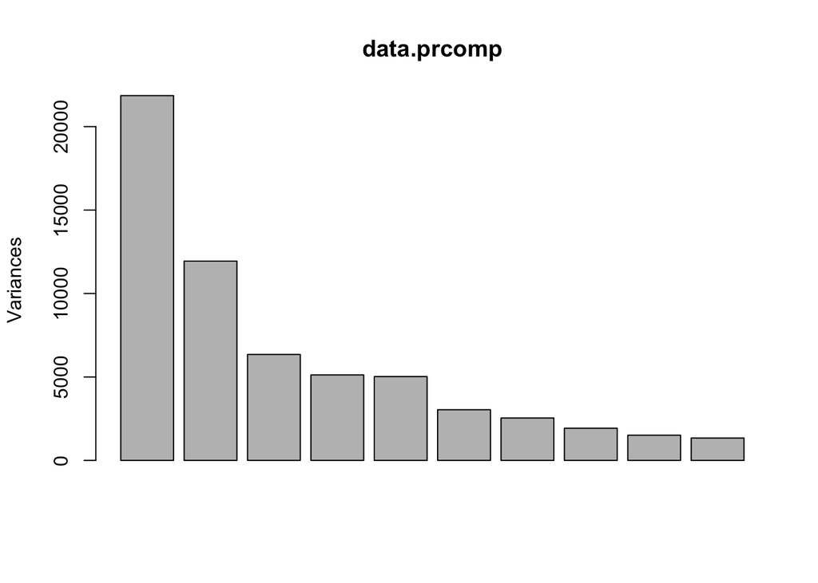

```r
#barchart of variance
plot(data.prcomp)
```

```r
#table of variance - shows proportion of variance
summary(data.prcomp)
```

```
## Importance of components:
##                             PC1      PC2      PC3      PC4      PC5      PC6
## Standard deviation     147.8444 109.2702 79.69016 71.57542 70.87593 55.11853
## Proportion of Variance   0.2595   0.1417  0.07538  0.06081  0.05963  0.03606
## Cumulative Proportion    0.2595   0.4012  0.47656  0.53737  0.59700  0.63306
##                             PC7      PC8      PC9     PC10     PC11     PC12
## Standard deviation     50.40571 43.91110 38.87431 36.60963 32.61610 31.32593
## Proportion of Variance  0.03016  0.02289  0.01794  0.01591  0.01263  0.01165
## Cumulative Proportion   0.66322  0.68611  0.70405  0.71996  0.73258  0.74423
##                            PC13    PC14     PC15     PC16     PC17     PC18
## Standard deviation     30.07893 28.4326 27.60102 26.21642 25.76683 24.69575
## Proportion of Variance  0.01074  0.0096  0.00904  0.00816  0.00788  0.00724
## Cumulative Proportion   0.75497  0.7646  0.77361  0.78177  0.78965  0.79689
##                            PC19     PC20     PC21     PC22     PC23     PC24
## Standard deviation     24.43511 23.45642 22.69303 22.26811 21.89859 21.23728
## Proportion of Variance  0.00709  0.00653  0.00611  0.00589  0.00569  0.00535
## Cumulative Proportion   0.80397  0.81051  0.81662  0.82250  0.82820  0.83355
##                            PC25     PC26     PC27     PC28     PC29     PC30
## Standard deviation     20.98578 20.80358 20.45134 19.97302 19.56670 19.54666
## Proportion of Variance  0.00523  0.00514  0.00496  0.00474  0.00454  0.00454
## Cumulative Proportion   0.83878  0.84391  0.84888  0.85361  0.85816  0.86269
##                            PC31     PC32     PC33     PC34     PC35     PC36
## Standard deviation     19.22319 19.12112 18.96156 18.84823 18.60491 18.51133
## Proportion of Variance  0.00439  0.00434  0.00427  0.00422  0.00411  0.00407
## Cumulative Proportion   0.86708  0.87142  0.87569  0.87990  0.88401  0.88808
##                            PC37     PC38     PC39     PC40     PC41     PC42
## Standard deviation     18.33122 18.26599 18.03637 17.97880 17.62595 17.58474
## Proportion of Variance  0.00399  0.00396  0.00386  0.00384  0.00369  0.00367
## Cumulative Proportion   0.89207  0.89603  0.89989  0.90373  0.90742  0.91109
##                            PC43     PC44     PC45     PC46     PC47     PC48
## Standard deviation     17.51842 17.39912 17.30631 17.21650 17.05619 16.99478
## Proportion of Variance  0.00364  0.00359  0.00356  0.00352  0.00345  0.00343
## Cumulative Proportion   0.91473  0.91832  0.92188  0.92540  0.92885  0.93228
##                            PC49     PC50    PC51     PC52     PC53     PC54
## Standard deviation     16.91030 16.79331 16.6810 16.51778 16.47176 16.24372
## Proportion of Variance  0.00339  0.00335  0.0033  0.00324  0.00322  0.00313
## Cumulative Proportion   0.93567  0.93902  0.9423  0.94556  0.94878  0.95191
##                            PC55     PC56     PC57     PC58    PC59     PC60
## Standard deviation     16.23197 16.09882 16.04894 15.93202 15.8932 15.78414
## Proportion of Variance  0.00313  0.00308  0.00306  0.00301  0.0030  0.00296
## Cumulative Proportion   0.95504  0.95812  0.96118  0.96419  0.9672  0.97014
##                            PC61     PC62     PC63     PC64     PC65    PC66
## Standard deviation     15.65431 15.58282 15.47904 15.45329 15.26293 15.0949
## Proportion of Variance  0.00291  0.00288  0.00284  0.00283  0.00277  0.0027
## Cumulative Proportion   0.97305  0.97593  0.97878  0.98161  0.98438  0.9871
##                            PC67     PC68     PC69     PC70     PC71      PC72
## Standard deviation     15.01461 14.88070 14.81961 14.57431 14.46657 5.591e-13
## Proportion of Variance  0.00268  0.00263  0.00261  0.00252  0.00248 0.000e+00
## Cumulative Proportion   0.98976  0.99239  0.99499  0.99752  1.00000 1.000e+00
```

```r
library(dplyr)
```

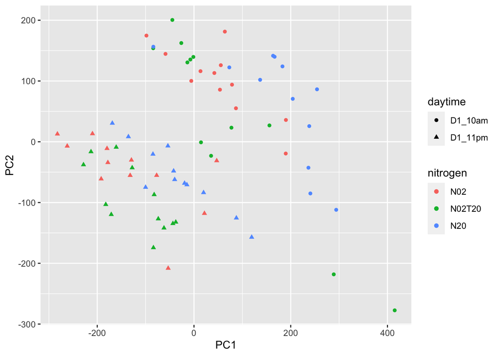

```r
library(ggplot2)
coords2draw = as.data.frame(data.prcomp$x)
coords2draw = cbind(coords2draw, samplegroups)

ggplot(coords2draw) +
  geom_point(mapping=aes(x = PC1, y= PC2,
                         col=nitrogen, shape=daytime))
```

## Clustering samples

### Hierarchical Clustering

In addition to identifying genes that have similar expression profiles, clustering can also be used to determine similarity between the different sample. This can be useful as a quality control step to ensure that the replicates are have a higher similarity to each other then the different sample. Additionally, to help label the different sample with the different levels of a factor, we can simply replace the colnames of the dataframe. Below is a hierarchical clustering of the samples with different labels.

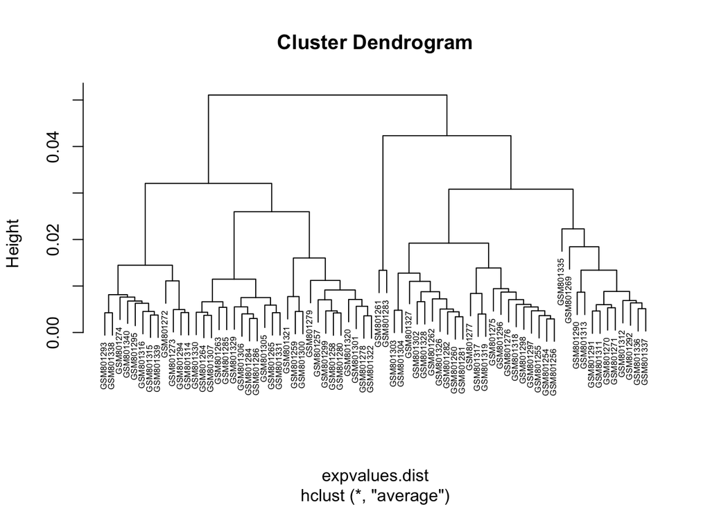

```r
expvalues.cor = cor(expvalues, method="pearson")
expvalues.dist = as.dist(1-expvalues.cor)
expvalues.clust = hclust(expvalues.dist, method="ave")
plot(expvalues.clust, cex=0.5)
```

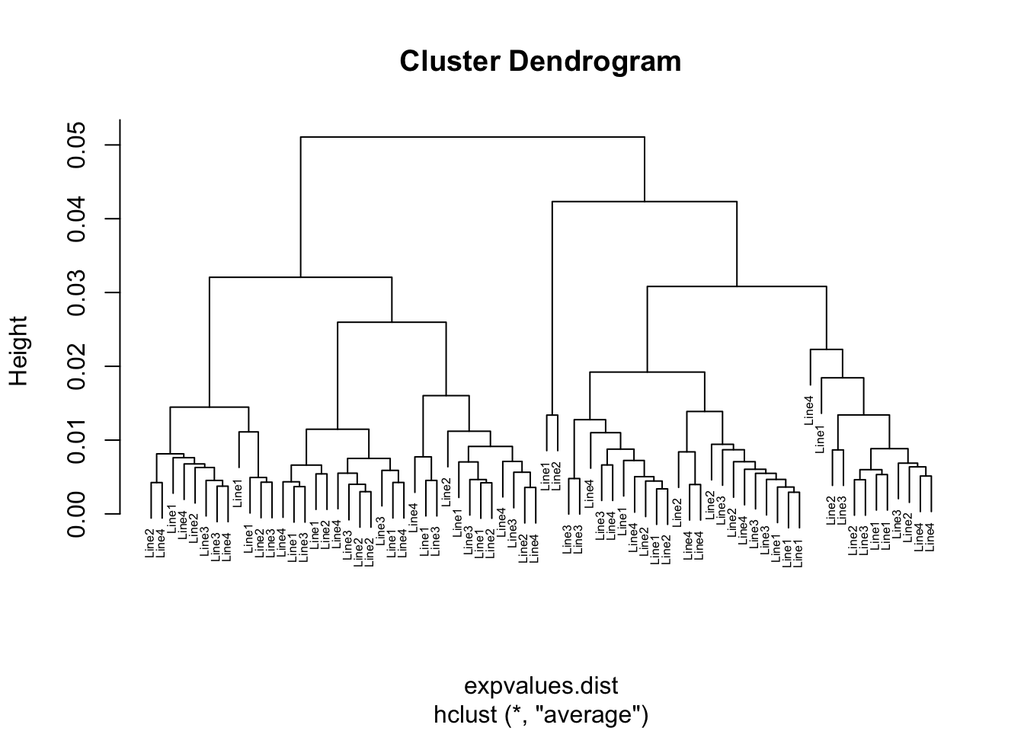

```r
expvalues.clust$labels = samplegroups$genotype
plot(expvalues.clust, cex=0.5)
```

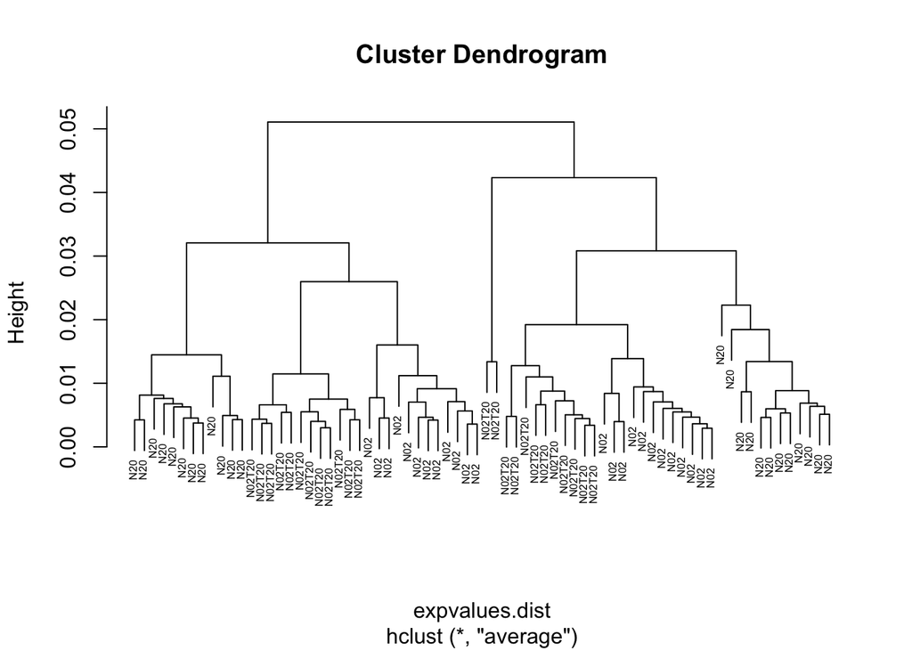

```r
expvalues.clust$labels = samplegroups$nitrogen
plot(expvalues.clust, cex=0.5)
```

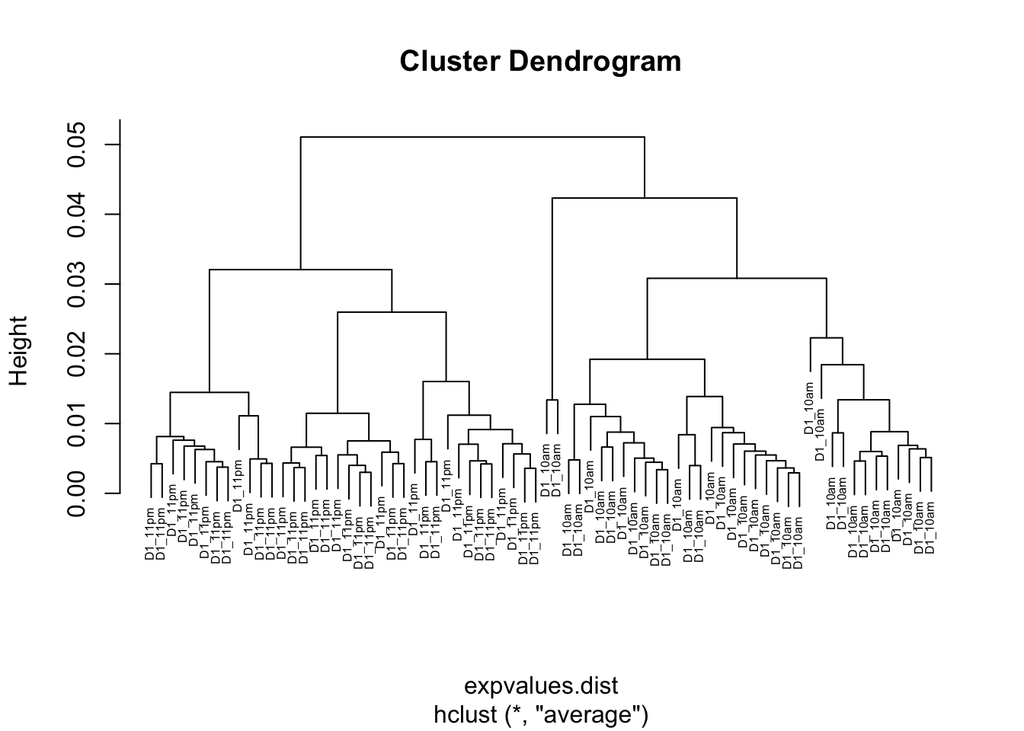

```r
expvalues.clust$labels = samplegroups$daytime
plot(expvalues.clust, cex=0.5)
```

Notice that the genotype does not seem to be driving the expression values for the different genes. The Nitrogen treatments appear to be clustering together. Even more interesting is that a subset of the nitrogen appear to be similar because of the time of collection. It appears as though our dataset has time and nitrogen interaction but not as much genotype interaction.

## Identifying differentially expressed genes

Now we can go back and cluster the genes. Performing a pairwise correlation on over 84,000 genes requires a lot of memory and time. We want to focus on genes that show differential expression. We can simply create an **ANOVA** model and identify genes that have signigicant models. First we will create a function that takes the expression values of a gene and also the different factors.

```r
#############################################
anova3way.mk <- function(expvector, vector1, vector2, vector3)
#############################################
#
# INPUT 1: expvector = numerical vector
#  vector1 is a vector defining the first parameter.
#  vector2 are same  as vector1 but for a different parameter.
#  vector3 are same  as vector1 but for a different parameter.
# OUTPUT: a dataframe of all p-values from all the data. The p-values are not fdr corrected.
#

{
# function is not assuming factors were provided so we just make sure here
  v1 = factor(vector1)
  v2 = factor(vector2)
  v3 = factor(vector3)
  temp.stats = numeric()

  # the model below is equivalent to v1*v2*v3 , however here we are explicit
  temp.lm=lm(expvector ~ v1* v2 * v3)

  #probability of the model can be calculated by retrieving the values for
  # performing fstatistics
  temp.fstat=summary(temp.lm)$fstatistic
  temp.model.value = pf( temp.fstat[1] , temp.fstat[2] , temp.fstat[3] , lower.tail=F )

  return(temp.model.value)
}


maizeanovapvalues = apply(expvalues, 1, anova3way.mk, samplegroups$genotype, samplegroups$nitrogen, samplegroups$daytime)


maizeanovapvalues_fdr = p.adjust(maizeanovapvalues, method="fdr")

siggenes = expvalues[(maizeanovapvalues_fdr<0.05),]

dim(siggenes)
```

```
## [1] 40156    72
```

As we can see, there is still quite a bit of genes that are significant based on our analysis. Thus instead of looking at a cutoff, letâs take 3,000 most significant genes.

```r
sorted_pvalues = sort(maizeanovapvalues, decreasing = F)
siggenes=expvalues[names(sorted_pvalues)[1:3000],]
dim(siggenes)
```

```
## [1] 3000   72
```

## Clustering differentially expressed genes

```r
siggenes.cor = cor(t(siggenes), method="pearson")
siggenes.dist = as.dist(1-siggenes.cor)
siggenes.clust = hclust(siggenes.dist, method="ave")
```

### Silhouette width

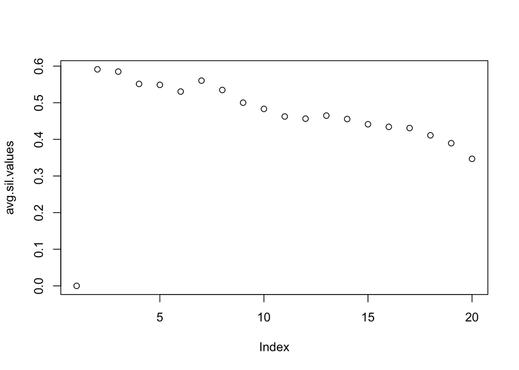

```r
library(cluster)
avg.sil.values=numeric()
avg.sil.values[1]=0
for (i in 2:20) {
  temp.clusters = cutree(siggenes.clust, k=i)
  silhouette(temp.clusters, dist=siggenes.dist)-> temp.cluster.sil
  avg.sil.values[i]=mean(temp.cluster.sil[,"sil_width"])
}

plot(avg.sil.values)
```

7 looks like a good number because of the small jump at the position

```r
siggroups = cutree(siggenes.clust, k=7)
table(siggroups)
```

```
## siggroups
##   1   2   3   4   5   6   7
## 747 387 810   3 870 155  28
```

We normally concern ourselves with the larger clusters. Letâs look at the heatmaps of a couple of cluster to see if we can understand the pattern of these genes.

### Heatmaps

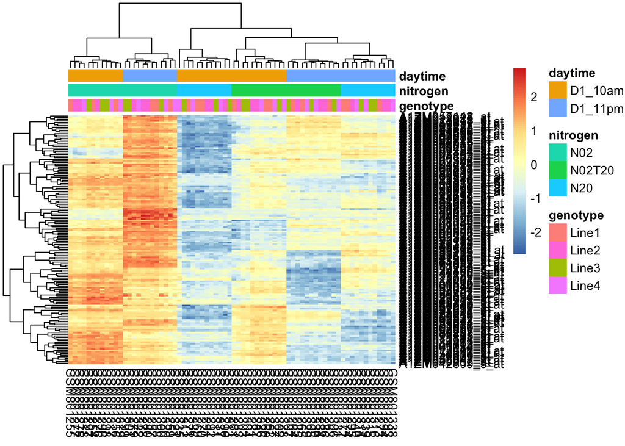

```r
library(pheatmap)

cluster2draw = siggenes[siggroups == 6,]
cluster2draw_scale = t(apply(cluster2draw,1,scale))
colnames(cluster2draw_scale) = colnames(cluster2draw)
pheatmap(cluster2draw_scale, annotation_col = samplegroups)
```

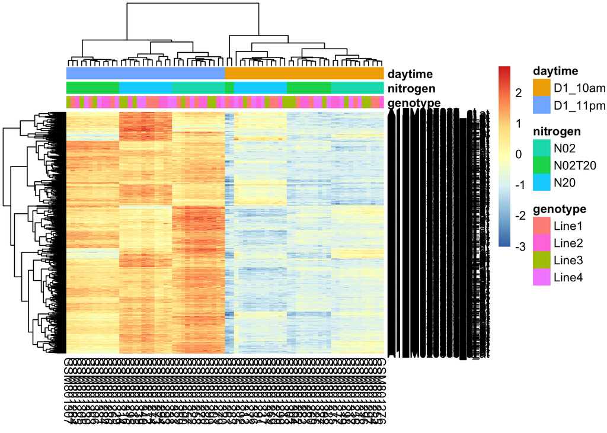

```r
cluster2draw = siggenes[siggroups == 1,]
cluster2draw_scale = t(apply(cluster2draw,1,scale))
colnames(cluster2draw_scale) = colnames(cluster2draw)
pheatmap(cluster2draw_scale, annotation_col = samplegroups)
```

## K-means clustering

K-means clustering does not require a distance object, instead it takes the original values and calculates euclidean distance between the points. For this reason it is important to first **scale** your data.

```r
siggenes_scale = t(apply(siggenes,1,scale))
siggenes_kmeans = kmeans(siggenes_scale, 7)
```

K-means results provide us with similar measurements as we calculated for hierarchical clustering calculated above and also the centers of the clusters.

```r
names(siggenes_kmeans)
```

```
## [1] "cluster"      "centers"      "totss"        "withinss"     "tot.withinss"
## [6] "betweenss"    "size"         "iter"         "ifault"
```

```r
table(siggenes_kmeans$cluster)
```

```
##
##   1   2   3   4   5   6   7
## 301 151 415 481 579 461 612
```

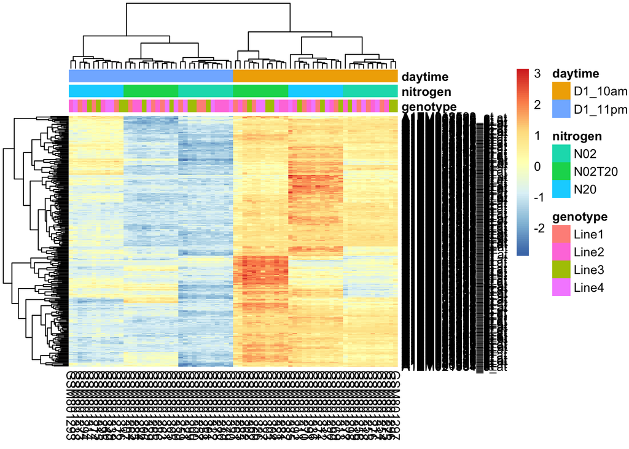

```r
library(pheatmap)
cluster2draw = siggenes[siggenes_kmeans$cluster == 1,]
cluster2draw_scale = t(apply(cluster2draw,1,scale))
colnames(cluster2draw_scale) = colnames(cluster2draw)
pheatmap(cluster2draw_scale, annotation_col = samplegroups)
```

## PCA of differentially expressed genes

To run the principal component analysis we will first transpose the data so that genes are the columns and the experiments are the rows. We will also center and scale the data before performing the analysis.

```r
data.prcomp = prcomp(t(siggenes), scale=TRUE, center=TRUE)

# your eigenvector is
head(data.prcomp$sdev)
```

```
## [1] 40.690066 25.741219 20.155429  9.274228  7.392188  6.548877
```

```r
# your rotation is how your values were modified in the different grid
data.prcomp$rotation[1:6,1:6]
```

```
##                          PC1         PC2          PC3           PC4
## A1ZM013667_at    0.023390686 0.007572389 -0.010922633 -0.0062086188
## A1ZM015359_at   -0.003399051 0.037490215  0.010085215 -0.0036479923
## A1ZM006439_a_at  0.022448122 0.010490163 -0.013566215 -0.0125306322
## A1ZM048024_at   -0.005474947 0.035006784  0.015018522  0.0144971783
## A1ZM067520_at   -0.003658893 0.037057770  0.011848826 -0.0005430515
## A1ZM039950_at    0.023220515 0.010095210 -0.007630568 -0.0102469896
##                           PC5           PC6
## A1ZM013667_at    0.0042272931 -0.0002657635
## A1ZM015359_at   -0.0040309336 -0.0042887246
## A1ZM006439_a_at  0.0023090673  0.0019697040
## A1ZM048024_at    0.0093954507 -0.0192350623
## A1ZM067520_at   -0.0008258007 -0.0099691351
## A1ZM039950_at   -0.0045712576  0.0079449800
```

```r
# your new values is in
data.prcomp$x[1:6.1:6]
```

```
## [1] -40.71643 -41.01297 -42.21922  42.72987  42.25053  33.75822
```

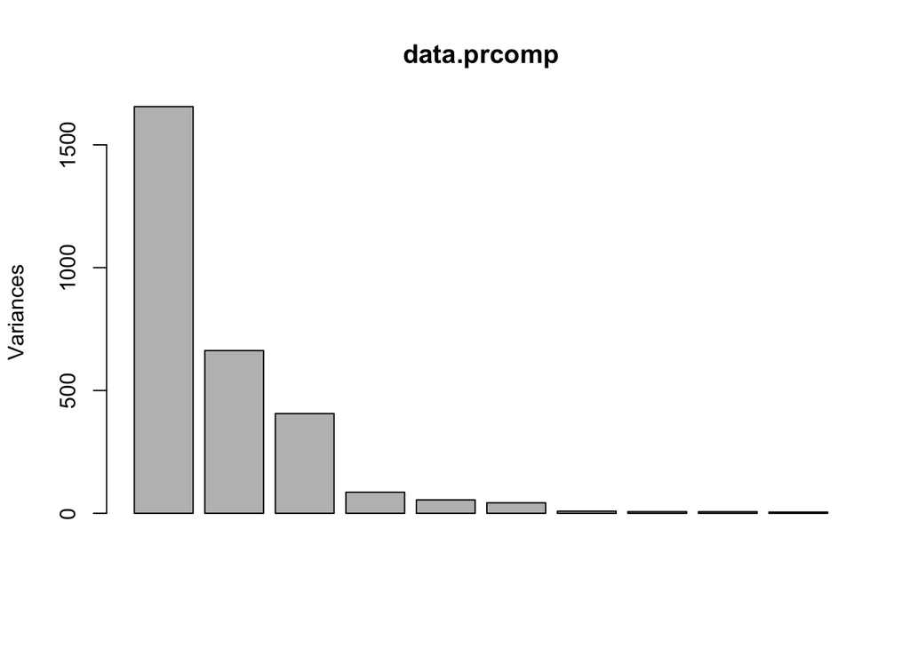

```r
#barchart of variance
plot(data.prcomp)
```

```r
#table of variance - shows proportion of variance
summary(data.prcomp)
```

```
## Importance of components:
##                            PC1     PC2     PC3     PC4     PC5    PC6     PC7
## Standard deviation     40.6901 25.7412 20.1554 9.27423 7.39219 6.5489 2.93325
## Proportion of Variance  0.5519  0.2209  0.1354 0.02867 0.01821 0.0143 0.00287
## Cumulative Proportion   0.5519  0.7728  0.9082 0.93685 0.95506 0.9694 0.97223
##                           PC8     PC9    PC10    PC11    PC12    PC13    PC14
## Standard deviation     2.6244 2.57996 2.23942 2.04504 1.91707 1.79960 1.74553
## Proportion of Variance 0.0023 0.00222 0.00167 0.00139 0.00123 0.00108 0.00102
## Cumulative Proportion  0.9745 0.97674 0.97841 0.97981 0.98103 0.98211 0.98313
##                           PC15    PC16    PC17    PC18    PC19    PC20    PC21
## Standard deviation     1.67290 1.50216 1.47012 1.40012 1.36542 1.34889 1.28653
## Proportion of Variance 0.00093 0.00075 0.00072 0.00065 0.00062 0.00061 0.00055
## Cumulative Proportion  0.98406 0.98481 0.98553 0.98619 0.98681 0.98741 0.98797
##                           PC22    PC23    PC24    PC25    PC26    PC27   PC28
## Standard deviation     1.26208 1.19834 1.17957 1.16212 1.14133 1.11351 1.0913
## Proportion of Variance 0.00053 0.00048 0.00046 0.00045 0.00043 0.00041 0.0004
## Cumulative Proportion  0.98850 0.98898 0.98944 0.98989 0.99032 0.99074 0.9911
##                           PC29    PC30    PC31    PC32    PC33    PC34    PC35
## Standard deviation     1.04431 1.03847 1.01103 0.99688 0.98982 0.96305 0.96145
## Proportion of Variance 0.00036 0.00036 0.00034 0.00033 0.00033 0.00031 0.00031
## Cumulative Proportion  0.99150 0.99186 0.99220 0.99253 0.99286 0.99316 0.99347
##                           PC36    PC37    PC38    PC39    PC40    PC41    PC42
## Standard deviation     0.93426 0.91210 0.89787 0.88062 0.87134 0.86066 0.84875
## Proportion of Variance 0.00029 0.00028 0.00027 0.00026 0.00025 0.00025 0.00024
## Cumulative Proportion  0.99376 0.99404 0.99431 0.99457 0.99482 0.99507 0.99531
##                           PC43    PC44    PC45    PC46    PC47   PC48    PC49
## Standard deviation     0.83582 0.82452 0.80773 0.80249 0.79235 0.7812 0.76284
## Proportion of Variance 0.00023 0.00023 0.00022 0.00021 0.00021 0.0002 0.00019
## Cumulative Proportion  0.99554 0.99577 0.99599 0.99620 0.99641 0.9966 0.99681
##                           PC50    PC51    PC52    PC53    PC54    PC55    PC56
## Standard deviation     0.75345 0.74658 0.73723 0.72785 0.71328 0.70960 0.69641
## Proportion of Variance 0.00019 0.00019 0.00018 0.00018 0.00017 0.00017 0.00016
## Cumulative Proportion  0.99700 0.99718 0.99736 0.99754 0.99771 0.99788 0.99804
##                           PC57    PC58    PC59    PC60    PC61    PC62    PC63
## Standard deviation     0.68933 0.68076 0.66636 0.66255 0.65089 0.63891 0.63432
## Proportion of Variance 0.00016 0.00015 0.00015 0.00015 0.00014 0.00014 0.00013
## Cumulative Proportion  0.99820 0.99835 0.99850 0.99865 0.99879 0.99892 0.99906
##                           PC64    PC65    PC66    PC67    PC68    PC69    PC70
## Standard deviation     0.61966 0.61660 0.61330 0.60495 0.59041 0.58617 0.56602
## Proportion of Variance 0.00013 0.00013 0.00013 0.00012 0.00012 0.00011 0.00011
## Cumulative Proportion  0.99919 0.99931 0.99944 0.99956 0.99968 0.99979 0.99990
##                          PC71      PC72
## Standard deviation     0.5562 3.119e-14
## Proportion of Variance 0.0001 0.000e+00
## Cumulative Proportion  1.0000 1.000e+00
```

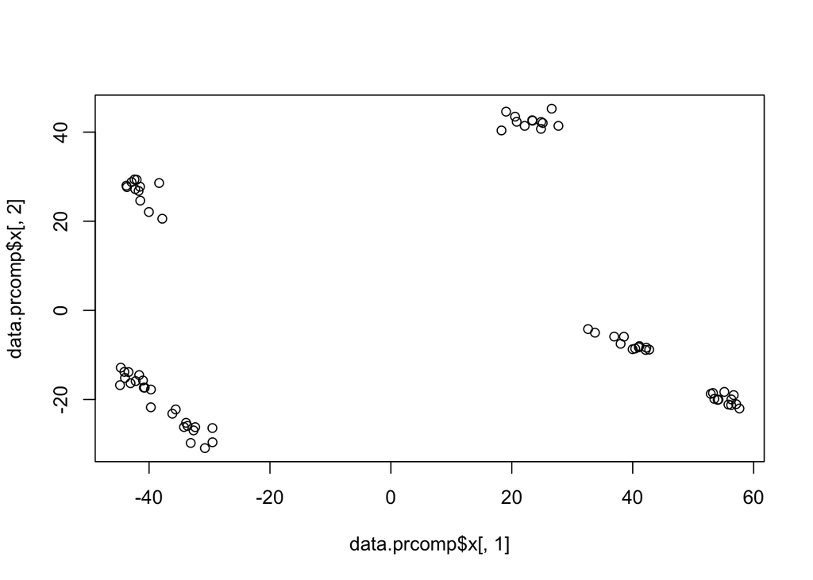

```r
#plotting the coordinates of first and second principal component
plot(data.prcomp$x[,1],data.prcomp$x[,2])
```

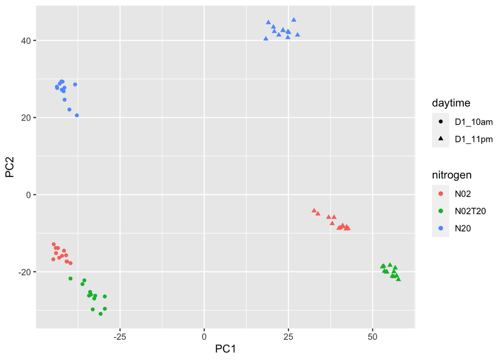

```r
library(dplyr)
library(ggplot2)
coords2draw = as.data.frame(data.prcomp$x)
coords2draw = cbind(coords2draw, samplegroups)

ggplot(coords2draw) +
  geom_point(mapping=aes(x = PC1, y= PC2,
                         col=nitrogen, shape=daytime))
```

# Conclusion

In summary, the steps to cluster any experimental data involves:

- Identify Differentially Expressed Genes
- Calculate distance (1-similarity)
- Perform Clustering
- Use silhouette width values to guide the determination of number of cluster groups
- visualize the clusters as heatmaps or boxplots.
- Perform PCA analysis

# t-SNE and umap

We will use the **M3C** package to perform *t-SNE* and *umap* reduction. You will see below that when you repeat the t-SNE plot, you will get different figures, however when using umap, the plot is the same.

```r
BiocManager::install("M3C")
```

*t-SNE* has a perplexity parameter which is set to 15 by default. You are welcome test different values to see if the results improve.

```r
library("M3C")
tsne(siggenes, labels = samplegroups$nitrogen)
```

```
## ***t-SNE wrapper function***
```

```
## running...
```

```
## done.
```

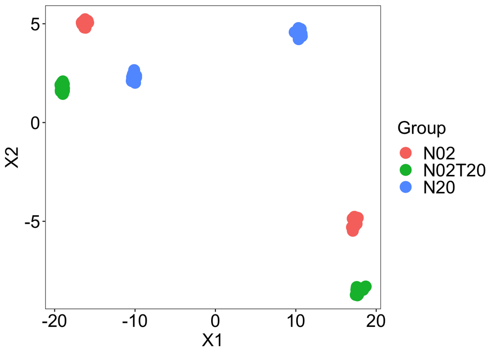

```r
tsne(siggenes, labels = samplegroups$nitrogen)
```

```
## ***t-SNE wrapper function***
```

```
## running...
```

```
## done.
```

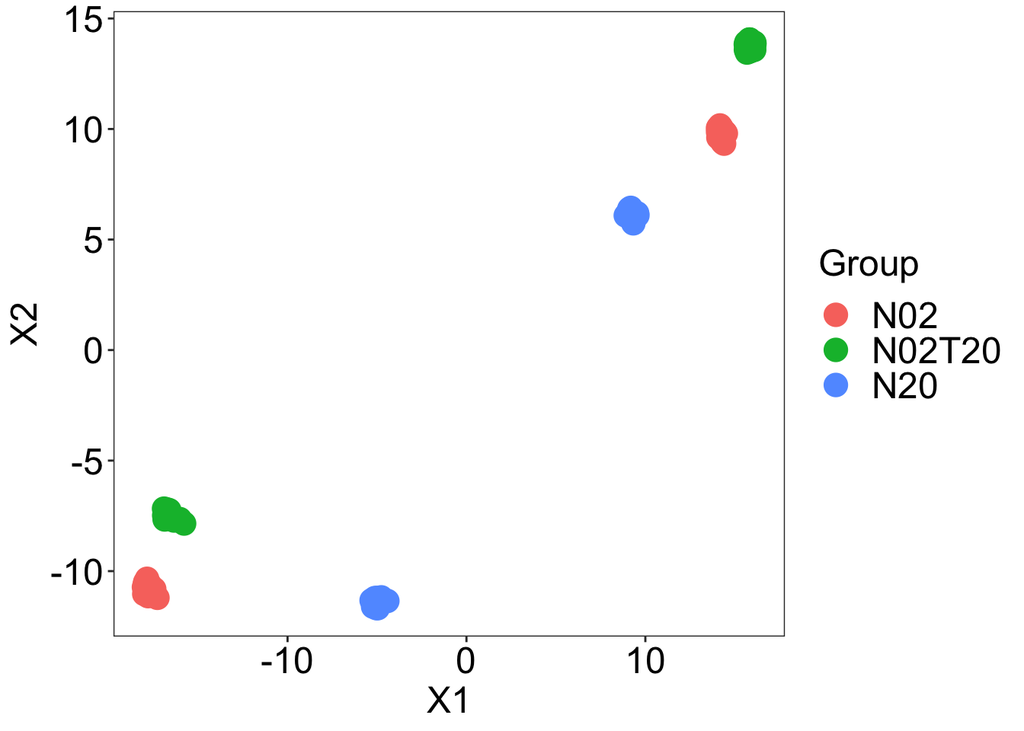

```r
tsne(siggenes, labels = samplegroups$daytime)
```

```
## ***t-SNE wrapper function***
```

```
## running...
```

```
## done.
```

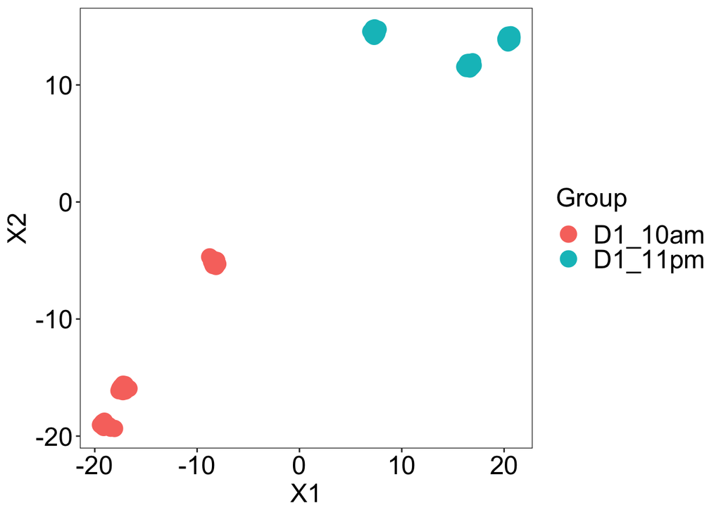

```r
umap(siggenes, labels = samplegroups$nitrogen)
```

```
## ***UMAP wrapper function***
```

```
## running...
```

```
## done.
```

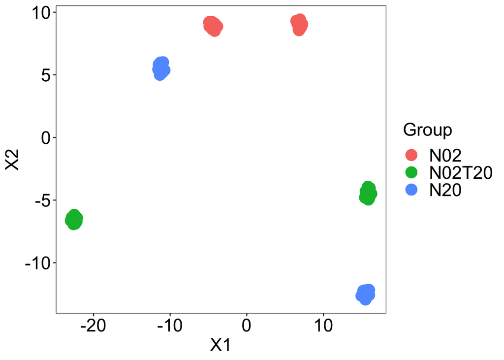

```r
umap(siggenes, labels = samplegroups$nitrogen)
```

```
## ***UMAP wrapper function***
```

```
## running...
```

```
## done.
```

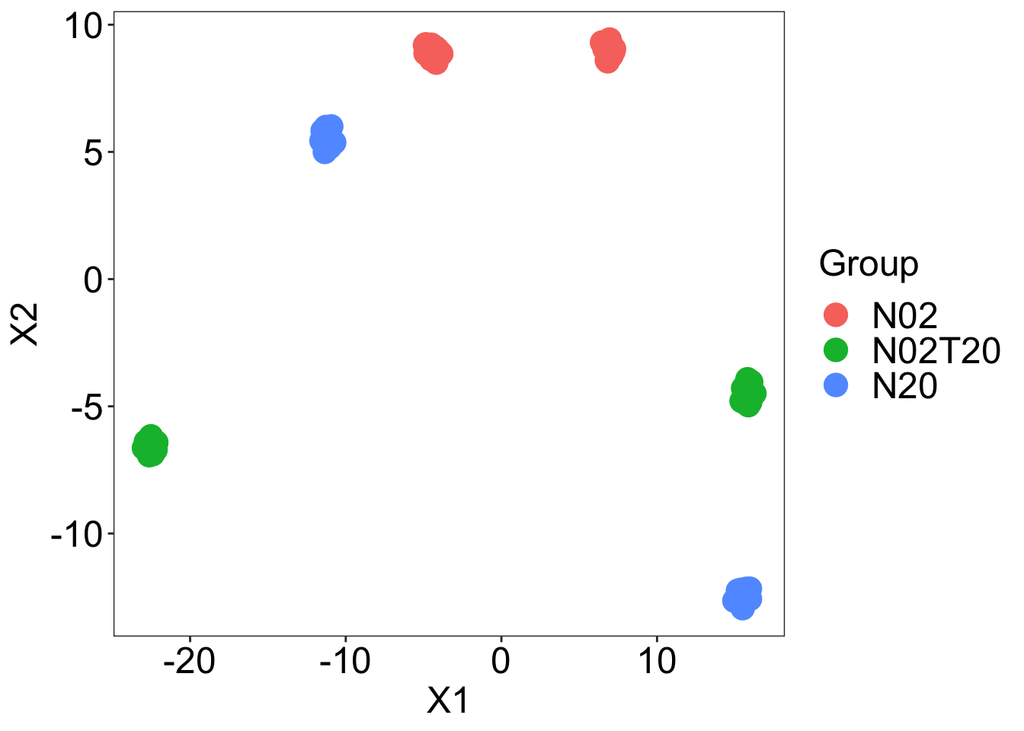

```r
umap(siggenes, labels = samplegroups$daytime)
```

```
## ***UMAP wrapper function***
```

```
## running...
```

```
## done.
```

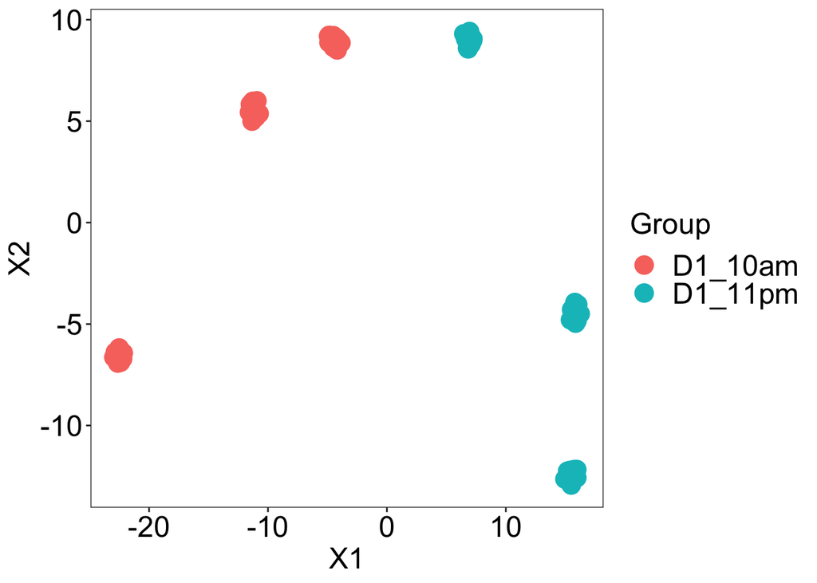

Letâs see who the two methods perform with full matrix ( no filtered genes)

```r
tsne(expvalues, labels=samplegroups$nitrogen)
```

```
## ***t-SNE wrapper function***
```

```
## running...
```

```
## done.
```

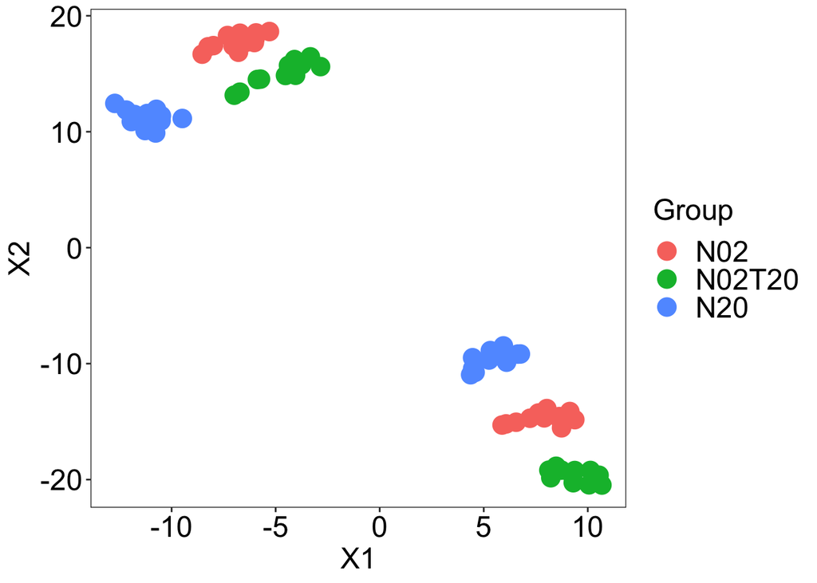

```r
tsne(expvalues, labels=samplegroups$daytime)
```

```
## ***t-SNE wrapper function***
```

```
## running...
```

```
## done.
```

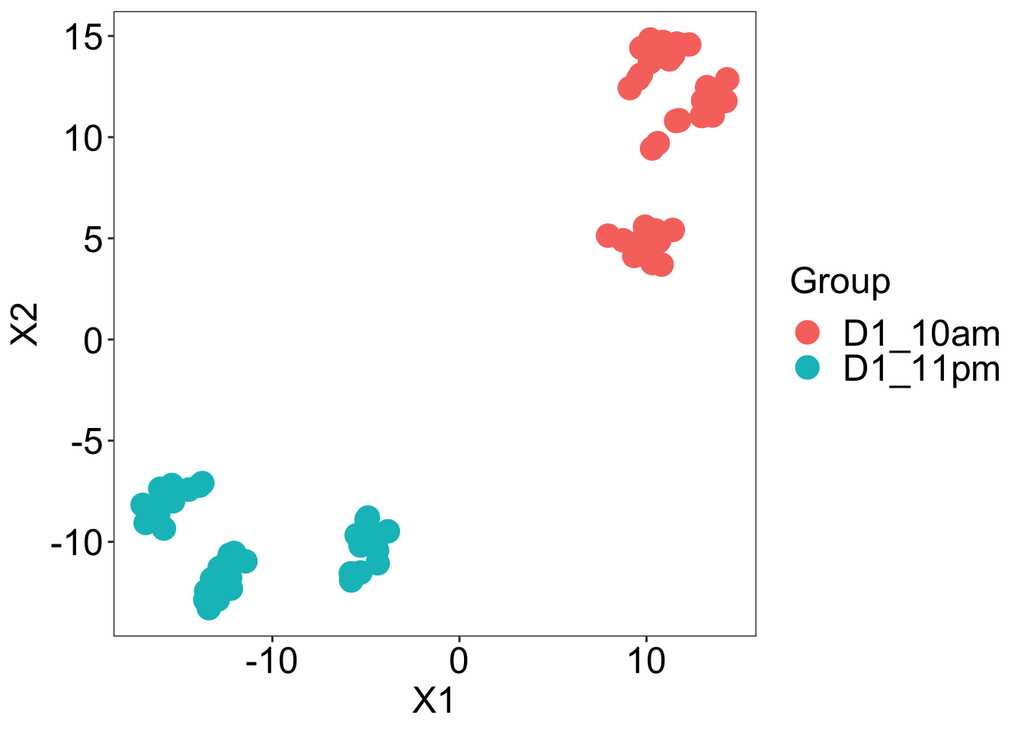

```r
umap(expvalues, labels=samplegroups$nitrogen)
```

```
## ***UMAP wrapper function***
```

```
## running...
```

```
## done.
```

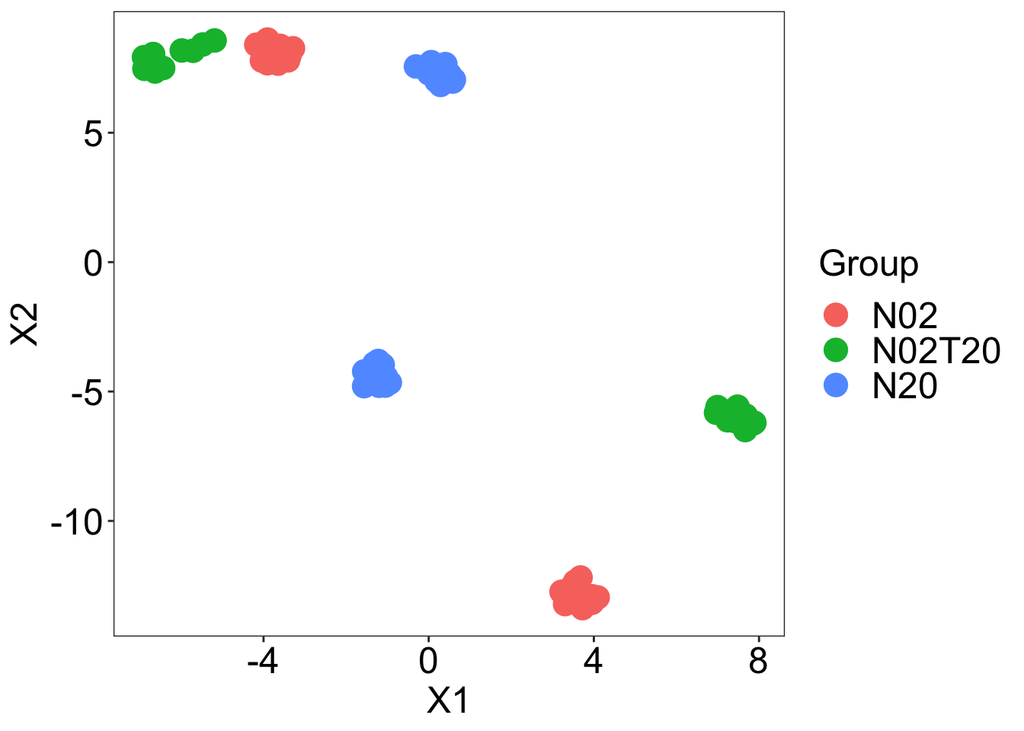

```r
umap(expvalues, labels=samplegroups$daytime)
```

```
## ***UMAP wrapper function***
```

```
## running...
```

```
## done.
```

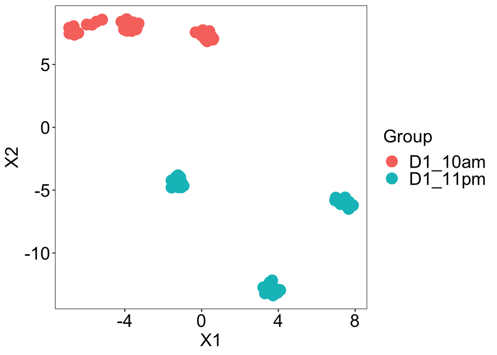

Both methods do a much better job in separating the groups with the entire dataset compared to PCA. UMAP goes further to suggest that the samples from 10am are much closer in expression than night time.